# AGU 2022 GEDI Workshop

[Workshop Icebreaker Activity](https://www.google.com/maps/d/edit?mid=1gcgmXzRRnkq1bmJ4N1ngiikf9P5ZKmE&usp=sharing)

[interactive chart not shown]

## Studying forest structure from space: An introduction to GEDI lidar data pre-processing and analysis in ecological applications

**Code authors:** Melissa Rose, Ivan Gonzalez, Jenna Keany $\\$$\\$

**Technical contributors:** Emma Reich, Shelby Sunquist, Patrick Jantz

The purpose of this workshop is to assist interested Ecologists, Biologists, and Geologists in accessing NASA’s Global Ecosystem Dynamics Investigation (GEDI) near-global lidar data and applying it to their research. We will review recent applications and discuss future directions for GEDI data. Using open-access R software, we will demonstrate how participants may easily access, manipulate, explore, assess, and apply GEDI data in their study areas. We will develop modules (download > cleaning > visualization, etc) and share code, inputs, and outputs to prevent bottlenecks in case of technical issues. This strategy allows attendees to participate in every module with products derived from previous stages even if previous steps/results weren’t completed. Participants may be required to install open-source software prior to the workshop. This workshop is organized primarily by PhD students in the Ecological and Environmental Informatics program at Northern Arizona University.

### Objectives

1. The primary objective of this workshop is to disseminate information on the use and functionality of spaceborne lidar (light detection and ranging) from GEDI, including: how the instrument functions, spatial resolution and coverage, available data products, where and how to access the data, and uses of lidar data in a variety of earth science subjects.
2. Participants will learn how to download GEDI data for an area of interest, process the data, and apply it to an ecological question in R.
3. Presenters will provide example code and intermediate data products so that participants can follow along and explore results in the event of technical challenges. $\\$$\\$$\\$$\\$

### To launch an interactive coding environment:

[figure not shown]

### To download this code, please refer to the workshop github:

https://github.com/IGSA-SICCS/GEDI_workshop

### Tutorial:

SECTION 0: PREPARE R ENVIRONMENT 0.1: Libraries

```r
#define which libraries to use
library(raster)
library(devtools)
library(sf)
library(sp)
library(data.table)
library(lidR)
library(httr)
library(tidyr)
library(curl)
library(hdf5r)
library(leaflet)
library(leafsync)
library(ggplot2)
library(RColorBrewer)
library(rasterVis)
library(viridis)
```

0.2: Directory and Subdirectories

```r
#define folder paths
wd <- getwd()

gL1B_dir <- './data/GEDI01_B.002/'
gL2A_dir <- './data/GEDI02_A.002/'
gL2B_dir <- './data/GEDI02_B.002/'
```

0.3: Source Scripts

```r
#source rGEDI functions in scripts directory
source('./scripts/gedi_functions.R')
```

SECTION 1: DOWNLOAD GEDI DATA FOR A REGION OF INTEREST 1.1: Define region of interest and date range

```r
#ROI: Columbia
#specify bounding box coordinates for ROI
ll_lon <- -75  #lower left longitude
ll_lat <- 0    #lower left latitude
ur_lon <- -74  #upper right longitude
ur_lat <- 1    #upper right latitude

#convert into bounding box coordinates
bbox <- paste(ll_lon, ll_lat, ur_lon, ur_lat, sep = ',')

#specify the date range to filter orbits by
daterange=c("2020-05-01","2020-07-31")
```

1.2: Visualize region of interest

```r
#view footprint locations for entire orbit on map
leaflet() %>%
  addRectangles(
    lng1=ll_lon, lat1=ll_lat,
    lng2=ur_lon, lat2=ur_lat,
    color = "grey",
    fillColor = "transparent") %>%
  addScaleBar(options = list(imperial = FALSE)) %>%
  addProviderTiles(providers$Esri.WorldImagery) %>%
  addLegend(colors = "grey", labels = "Region of Interest")
```

[interactive chart not shown]

1.3: Use gedi_finder to find overlapping GEDI orbits

```r
#create a list of all overlapping orbits for each GEDI data product
gL1B <- gedi_finder('GEDI01_B.002', bbox)
```

```
## [1] "Found 157 GEDI01_B.002 overlapping orbits found."
```

```r
gL2A <- gedi_finder('GEDI02_A.002', bbox)
```

```
## [1] "Found 157 GEDI02_A.002 overlapping orbits found."
```

```r
gL2B <- gedi_finder('GEDI02_B.002', bbox)
```

```
## [1] "Found 157 GEDI02_B.002 overlapping orbits found."
```

1.4 Use gedi_temp_filter to subset orbit list within date range

```r
#subset orbit list using daterange
gL1B <- gedi_temp_filter(gL1B, 'GEDI01_B.002', daterange)
```

```
## [1] "Found 21 GEDI01_B.002 overlapping orbits from 2020-05-01 to 2020-07-31."
```

```r
gL2A <- gedi_temp_filter(gL2A, 'GEDI02_A.002', daterange)
```

```
## [1] "Found 21 GEDI02_A.002 overlapping orbits from 2020-05-01 to 2020-07-31."
```

```r
gL2B <- gedi_temp_filter(gL2B, 'GEDI02_B.002', daterange)
```

```
## [1] "Found 21 GEDI02_B.002 overlapping orbits from 2020-05-01 to 2020-07-31."
```

1.5: Use gedi_download to download GEDI data (DO NOT RUN)

```r
#download data product to their output data directory
gedi_download(filepath=gL1B,outdir=gL1B_dir)
gedi_download(filepath=gL2A,outdir=gL2A_dir)
gedi_download(filepath=gL2B,outdir=gL2B_dir)
```

SECTION 2: CLIP GEDI DATA PRODUCTS TO REGION OF INTEREST 2.1 Read GEDI data (DO NOT RUN)

```r
#read the level 1B, 2A, and 2B for a single orbit
gedilevel1B <- readLevel1B(level1Bpath = paste0(gL1B_dir,"GEDI01_B_2020160005619_O08428_03_T01337_02_005_01_V002.h5"))
gedilevel2A <- readLevel2A(level2Apath = paste0(gL2A_dir,"GEDI02_A_2020160005619_O08428_03_T01337_02_003_01_V002.h5"))
gedilevel2B <- readLevel2B(level2Bpath = paste0(gL2B_dir,"GEDI02_B_2020160005619_O08428_03_T01337_02_003_01_V002.h5"))
```

2.2 Clip data within bbox coordinates (DO NOT RUN)

```r
gedilevel1B <- clipLevel1B(gedilevel1B, ll_lon, ur_lon, ll_lat, ur_lat,
                                output = paste0(gL1B_dir,"GEDI01_B_2020160005619_O08428_03_T01337_02_005_01_V002_clip.h5"))
gedilevel2A <- clipLevel2A(gedilevel2A, ll_lon, ur_lon, ll_lat, ur_lat,
                                output = paste0(gL2A_dir,"GEDI02_A_2020160005619_O08428_03_T01337_02_003_01_V002_clip.h5"))
gedilevel2B <- clipLevel2B(gedilevel2B, ll_lon, ur_lon, ll_lat, ur_lat,
                                output = paste0(gL2B_dir,"GEDI02_B_2020160005619_O08428_03_T01337_02_003_01_V002_clip.h5"))
```

###START HERE###

```r
gedilevel1B <- readLevel1B(level1Bpath = paste0(gL1B_dir,"GEDI01_B_2020160005619_O08428_03_T01337_02_005_01_V002_clip.h5"))
gedilevel2A <- readLevel2A(level2Apath = paste0(gL2A_dir,"GEDI02_A_2020160005619_O08428_03_T01337_02_003_01_V002_clip.h5"))
gedilevel2B <- readLevel2B(level2Bpath = paste0(gL2B_dir,"GEDI02_B_2020160005619_O08428_03_T01337_02_003_01_V002_clip.h5"))
```

2.3 Use GEDI L2A quality flag to select only quality shots

```r
#read GEDI L2A data into data.table
level2AM <- getLevel2AM(gedilevel2A)
dim(level2AM)
```

```
## [1] 3403  112
```

```r
#convert shot_number from integer to character
level2AM$shot_number <- paste0(level2AM$shot_number)

#filtering for quality_flag == 1
level2AM_qual <- level2AM[quality_flag == 1]
dim(level2AM_qual)
```

```
## [1] 3323  112
```

2.4 Visualize location of quality filtered GEDI footprints

```r
#view footprint locations for entire orbit on map
leaflet() %>%
  addRectangles(
    lng1=ll_lon, lat1=ll_lat,
    lng2=ur_lon, lat2=ur_lat,
    color = "grey",
    fillColor = "transparent") %>%
  addCircleMarkers(level2AM[quality_flag == 0, lon_lowestmode],
                   level2AM[quality_flag == 0, lat_lowestmode],
                   radius = 1,
                   opacity = 0.5,
                   color = "red",
                   popup = paste0("shot_number: ", level2AM$shot_number))  %>%
  addCircleMarkers(level2AM_qual$lon_lowestmode,
                   level2AM_qual$lat_lowestmode,
                   radius = 1,
                   opacity = 0.5,
                   color = "blue",
                   popup = paste0("shot_number: ", level2AM_qual$shot_number))  %>%
  addScaleBar(options = list(imperial = FALSE)) %>%
  addProviderTiles(providers$Esri.WorldImagery) %>%
  addLegend(colors = c("grey", "blue", "red"), labels = c("Region of Interest", "Quality GEDI Footprints", "Non-Quality GEDI Footprints"))
```

[interactive chart not shown]

2.4 Select individual footprints along a structurally heterogeneous gradient

```r
sample_region <- level2AM_qual[shot_number %in% c("84280500300242755", "84280500300242756", "84280500300242757", "84280500300242758", "84280500300242759")]

#view footprint in sample region
leaflet() %>%
  addRectangles(
    lng1=min(sample_region$lon_lowestmode)-0.00025, lat1=min(sample_region$lat_lowestmode)-0.00025,
    lng2=max(sample_region$lon_lowestmode)+0.00025, lat2=max(sample_region$lat_lowestmode)+0.00025,
    color = "grey",
    fillColor = "transparent") %>%
  addCircleMarkers(sample_region$lon_lowestmode,
                   sample_region$lat_lowestmode,
                   radius = 25,
                   weight = 2,
                   fillColor = "transparent",
                   color = "blue",
                   popup = paste0("shot_number: ", sample_region$shot_number))  %>%
  addScaleBar(options = list(imperial = FALSE)) %>%
  addProviderTiles(providers$Esri.WorldImagery) %>%
  addLegend(colors = c("grey", "blue"), labels = c("Sample Region", "GEDI Footprints"))
```

[interactive chart not shown]

SECTION 3: Visualize GEDI Data Products 3.1 Plot GEDIL1B Full Waveform

```r
#select shot_numbers for different cover types
shotnum_forest <- "84280500300242756"
shotnum_edge <- "84280500300242757"
shotnum_grass <- "84280500300242758"

#get waveform data for each selected footprint
wf_forest <- getLevel1BWF(gedilevel1B, shot_number=shotnum_forest)
wf_edge <- getLevel1BWF(gedilevel1B, shot_number=shotnum_edge)
wf_grass <- getLevel1BWF(gedilevel1B, shot_number=shotnum_grass)
```

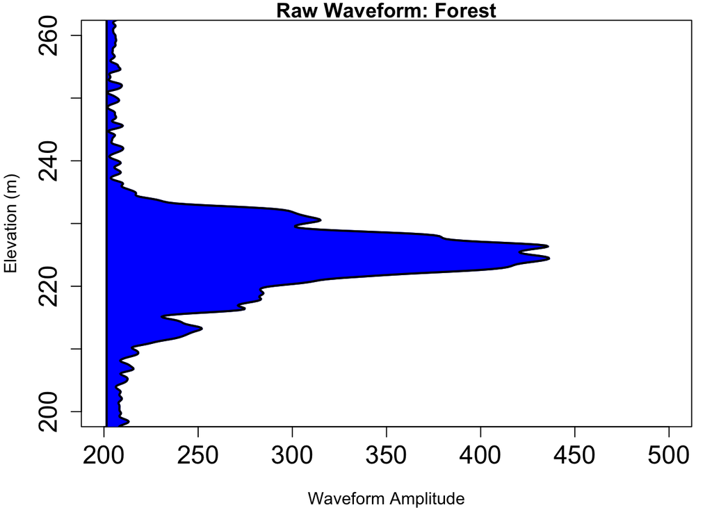

```r
#plot raw waveforms
par(mfrow = c(1,1), mar=c(4,4,1,1), cex.axis = 1.5)

plot(wf_forest, relative=FALSE, polygon=TRUE, type="l", lwd=2, col="blue",
    xlab="Waveform Amplitude", ylab="Elevation (m)", main="Raw Waveform: Forest", xlim=c(200,500), ylim=c(200,260))
```

[figure not shown]

```r
plot(wf_edge, relative=FALSE, polygon=TRUE, type="l", lwd=2, col="blue",
    xlab="Waveform Amplitude", ylab="Elevation (m)", main="Raw Waveform: Edge", xlim=c(200,500), ylim=c(200,260), add = TRUE)
```

[figure not shown]

```r
plot(wf_grass, relative=FALSE, polygon=TRUE, type="l", lwd=2, col="blue",
    xlab="Waveform Amplitude", ylab="Elevation (m)", main="Raw Waveform: Grass", xlim=c(200,500), ylim=c(200,260), add = TRUE)
```

3.2 Plot GEDIL2A Elevation and Height Metrics

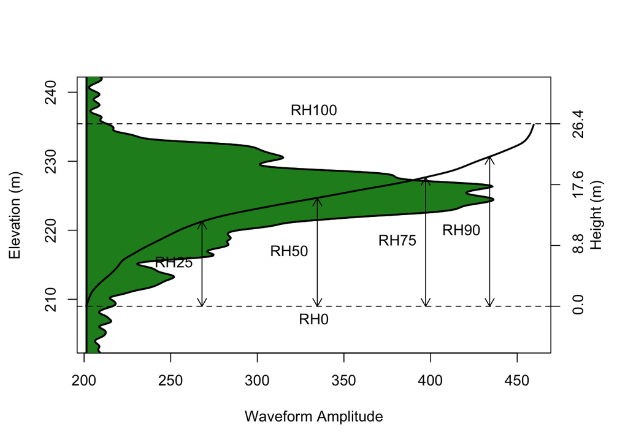

```r
#plot waveform with GEDIL2A relative height metrics
plotWFMetrics(gedilevel1B, gedilevel2A, shotnum_forest, rh=c(25, 50, 75, 90))
```

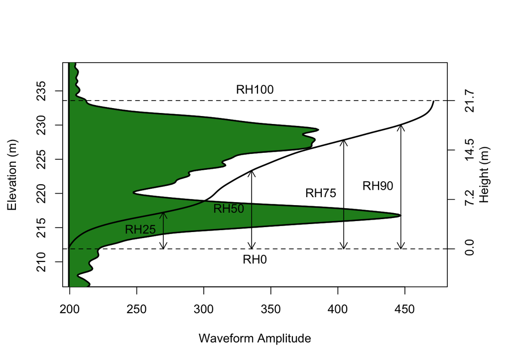

```r
plotWFMetrics(gedilevel1B, gedilevel2A, shotnum_edge, rh=c(25, 50, 75, 90))
```

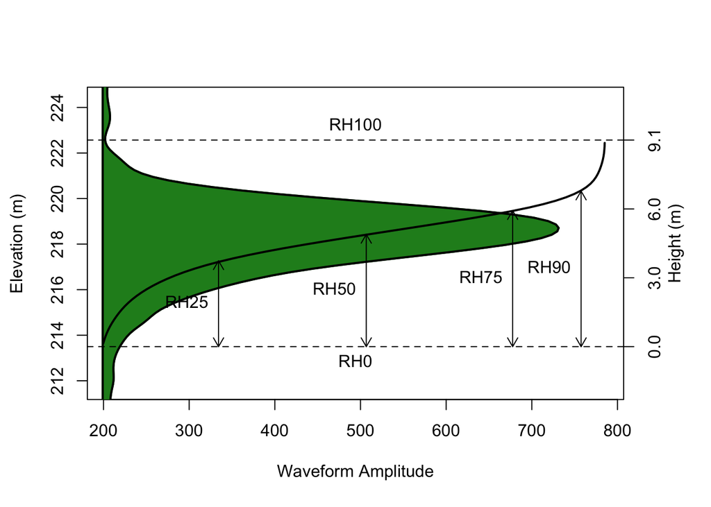

```r
plotWFMetrics(gedilevel1B, gedilevel2A, shotnum_grass, rh=c(25, 50, 75, 90))
```

```r
#get canopy cover and vertical profile metrics
level2BVPM <- getLevel2BVPM(gedilevel2B)
dim(level2BVPM)
```

```
## [1] 3403   19
```

```r
#filtering for quality_flag == 1
level2BVPM <- level2BVPM[l2b_quality_flag == 1]
dim(level2BVPM)
```

```
## [1] 3320   19
```

```r
#removing NA values
level2BVPM$pai[level2BVPM$pai==-9999]<-NA # assigning NA to -9999
dim(level2BVPM)
```

```
## [1] 3320   19
```

```r
#get pai profile metrics
level2BPAIProfile <- getLevel2BPAIProfile(gedilevel2B)
dim(level2BPAIProfile)
```

```
## [1] 3403   41
```

```r
#filtering for quality_flag == 1
level2BPAIProfile <- level2BPAIProfile[l2b_quality_flag == 1]
dim(level2BPAIProfile)
```

```
## [1] 3320   41
```

```r
#convert shot_number from integer to character
level2BPAIProfile$shot_number <- paste0(level2BPAIProfile$shot_number)

#plot Level2B PAI Profile
#gPAIprofile <- plotPAIProfile(level2BPAIProfile, beam="BEAM0101", elev=TRUE)
```

```r
#get pavd profile metrics
level2BPAVDProfile <- getLevel2BPAVDProfile(gedilevel2B)
dim(level2BPAVDProfile)
```

```
## [1] 3403   41
```

```r
#filtering for quality_flag == 1
level2BPAVDProfile <- level2BPAVDProfile[l2b_quality_flag == 1]
dim(level2BPAVDProfile)
```

```
## [1] 3320   41
```

```r
#plot Level2B PAVD Profile
#gPAVDprofile<-plotPAVDProfile(level2BPAVDProfile, beam="BEAM0101", elev=TRUE)
```

SECTION 4: Create Raster Layers 4.1 Compute Descriptive Statistics

```r
#compute a series of statistics for GEDI relative height metrics
rh100metrics_st <- polyStatsLevel2AM(level2AM_qual, func=SetOfMetrics(rh100))

#compute a series of statistics for GEDI canopy cover metrics
cover_metrics_st <- polyStatsLevel2BVPM(level2BVPM, func=SetOfMetrics(cover))
```

4.1 Compute Descriptive Height Stats

```r
#compute a series of statistics for GEDI relative height metrics
rh100metrics <- gridStatsLevel2AM(level2AM_qual, func=SetOfMetrics(rh100), res=0.010)
```

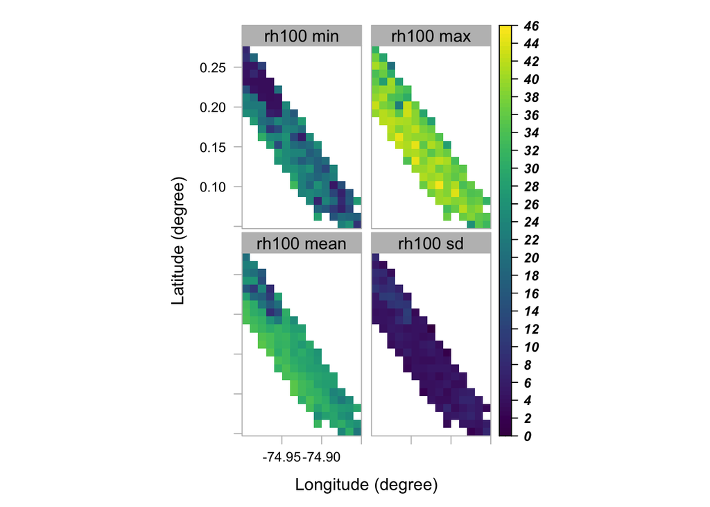

```r
#plot rh100 stats
rh100maps <- levelplot(rh100metrics,
                     layout=c(2, 2),
                     margin=FALSE,
                     xlab = "Longitude (degree)", ylab = "Latitude (degree)",
                     colorkey=list(
                       space='right',
                       labels=list(at=seq(0, 46, 2), font=4),
                       axis.line=list(col='black'),
                       width=1),
                     par.settings=list(
                       strip.border=list(col='gray'),
                       strip.background=list(col='gray'),
                       axis.line=list(col='gray')
                     ),
                     scales=list(draw=TRUE),
                     col.regions=viridis,
                     at=seq(0, 46, len=101),
                     names.attr=c("rh100 min","rh100 max","rh100 mean", "rh100 sd"))
rh100maps
```

4.2 Compute Descriptive Canopy Cover Stats

```r
#compute a series of statistics for GEDI plant area index
pai_metrics <- gridStatsLevel2BVPM(level2BVPM = level2BVPM, func=SetOfMetrics(pai), res=0.010)
fhd_metrics <- gridStatsLevel2BVPM(level2BVPM = level2BVPM, func=SetOfMetrics(fhd_normal), res=0.010)
cover_metrics <- gridStatsLevel2BVPM(level2BVPM = level2BVPM, func=SetOfMetrics(cover), res=0.010)
```

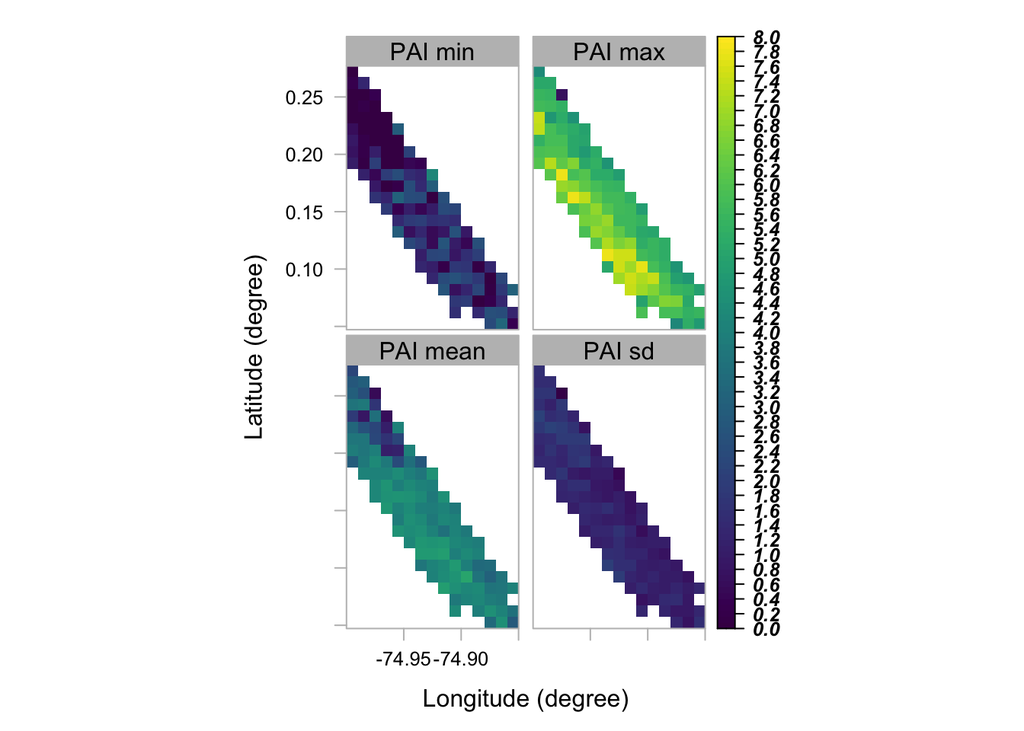

```r
#plot pai stats
pai_maps <- levelplot(pai_metrics,
                    layout=c(2, 2),
                    margin=FALSE,
                    xlab = "Longitude (degree)", ylab = "Latitude (degree)",
                    colorkey=list(
                      space='right',
                      labels=list(at=seq(0, 8, 0.2), font=4),
                      axis.line=list(col='black'),
                      width=1),
                    par.settings=list(
                      strip.border=list(col='gray'),
                      strip.background=list(col='gray'),
                      axis.line=list(col='gray')
                    ),
                    scales=list(draw=TRUE),
                    col.regions=viridis,
                    at=seq(0, 8, len=101),
                    names.attr=c("PAI min","PAI max","PAI mean", "PAI sd"))
pai_maps
```

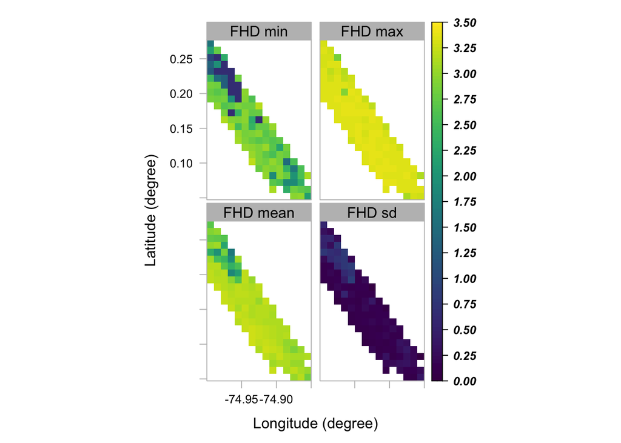

```r
#plot fhd stats
fhd_maps <- levelplot(fhd_metrics,
                    layout=c(2, 2),
                    margin=FALSE,
                    xlab = "Longitude (degree)", ylab = "Latitude (degree)",
                    colorkey=list(
                      space='right',
                      labels=list(at=seq(0, 3.5, 0.25), font=4),
                      axis.line=list(col='black'),
                      width=1),
                    par.settings=list(
                      strip.border=list(col='gray'),
                      strip.background=list(col='gray'),
                      axis.line=list(col='gray')
                    ),
                    scales=list(draw=TRUE),
                    col.regions=viridis,
                    at=seq(0, 3.5, len=101),
                    names.attr=c("FHD min","FHD max","FHD mean", "FHD sd"))
fhd_maps
```

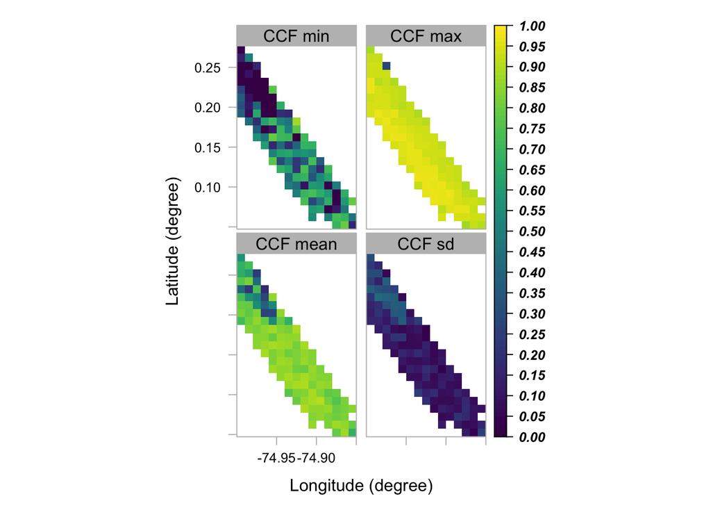

```r
#plot cover stats
cover_maps <- levelplot(cover_metrics,
                    layout=c(2, 2),
                    margin=FALSE,
                    xlab = "Longitude (degree)", ylab = "Latitude (degree)",
                    colorkey=list(
                      space='right',
                      labels=list(at=seq(0, 1, 0.05), font=4),
                      axis.line=list(col='black'),
                      width=1),
                    par.settings=list(
                      strip.border=list(col='gray'),
                      strip.background=list(col='gray'),
                      axis.line=list(col='gray')
                    ),
                    scales=list(draw=TRUE),
                    col.regions=viridis,
                    at=seq(0, 1, len=101),
                    names.attr=c("CCF min","CCF max","CCF mean", "CCF sd"))
cover_maps
```